# Homework 1

## Finance 372 - Prof Travis Johnson

**Videos**: Programming skills you'll need for this assignment are covered in videos 1 through 8 on the YouTube channel https://www.youtube.com/channel/UCm8Lrbs8DkIZ8OHa0VpK2hQ

**Rules**: you must complete this assignment on your own but are allowed to consult lecture notes, the class YouTube channel, other internet resources, and other students via the Discord Channel. If you are using code copies from a website, cite that website. You are still responsible for the quality of the code submitted - it's *your* fault if you copy an unreliable resource

**Deliverables**: submit a .html copy (File -> Export Notebook As -> Export Notebook to HTML). The HTML file must be readable and include all the output you want us to grade. We will **not** run your code for you, and you will **not** receive credit for solutions that are in code format but do not have readable output in the HTML file.

## Solution by: Siyuan Yang SY9734

## Task 1: Load MSFT.csv into a DataFrame and show a preview of its content

```python
import pandas as pd
df = pd.read_csv('MSFT.csv')
df.head
df.tail
df.describe
```

```
<bound method NDFrame.describe of            Date        Open        High         Low       Close   Adj Close  \
0      1/2/2020  158.779999  160.729996  158.330002  160.619995  158.936279
1      1/3/2020  158.320007  159.949997  158.059998  158.619995  156.957260
2      1/6/2020  157.080002  159.100006  156.509995  159.029999  157.362961
3      1/7/2020  159.320007  159.669998  157.320007  157.580002  155.928177
4      1/8/2020  158.929993  160.800003  157.949997  160.089996  158.411835
..          ...         ...         ...         ...         ...         ...
247  12/23/2020  223.110001  223.559998  220.800003  221.020004  221.020004
248  12/24/2020  221.419998  223.610001  221.199997  222.750000  222.750000
249  12/28/2020  224.449997  226.029999  223.020004  224.960007  224.960007
250  12/29/2020  226.309998  227.179993  223.580002  224.149994  224.149994
251  12/30/2020  225.229996  225.630005  221.470001  221.679993  221.679993

       Volume
0    22622100
1    21116200
2    20813700
3    21634100
4    27746500
..        ...
247  18699600
248  10550600
249  17933500
250  17403200
251  20272300

[252 rows x 7 columns]>
```

## Task 2: Plot MSFT's adjusted close over 2020

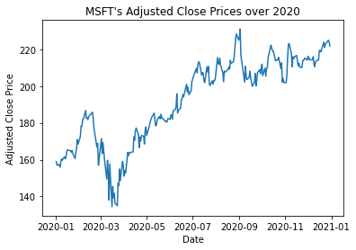

```python
import matplotlib.pyplot as plt
df = pd.read_csv('MSFT.csv')
df['Date'] = pd.to_datetime(df['Date'])
#df_2020 = df[df['Date'].str.contain(2020)]
plt.plot(df['Date'],df['Adj Close'])
plt.xlabel("Date")
plt.ylabel("Adjusted Close Price")
plt.title("MSFT's Adjusted Close Prices over 2020")
```

## Task 3: Calculate MSFT's daily returns from adjusted close prices. Using these daily returns, find and present:

- Arithmetic average daily return (in annualized % units)
- Geometric average daily return (in annualized % units)
- Standard deviation of daily returns (in annualized % units)
- Sharpe Ratio of daily returns, (in annualized % units)

When calculating the Sharpe Ratio, it's safe in this instance to assume the risk-free rate is 0%.

Note that the `gmean` function from the videos requires no `NaN` values. A quick way to make this happen is using the `dropna()` function (https://pandas.pydata.org/pandas-docs/stable/reference/api/pandas.DataFrame.dropna.html)

```python
# Solution to Task 3
import pandas as pd
import numpy as np
import math
import scipy.stats as stats

df = pd.read_csv('MSFT.csv')
df['Returns'] = df['Adj Close'].pct_change()
ri = df.loc[:,'Returns']
ann_arith_mean = ri.mean()*252
ann_std = ri.std()*(252**0.5)
ann_ge_mean = stats.gmean(ri.dropna()+1)**252-1
sr = ann_arith_mean/ann_std
print('Arithmetic Average: {:.1f}%'.format(100*ann_arith_mean))
print('Standard Deviation: {:.1f}%'.format(100*ann_std))
print('Geometric Means: {:.1f}%'.format(100*ann_ge_mean))
print('Sharpe Ratio: {:.2f}%'.format(100*sr))
```

```
Arithmetic Average: 43.1%
Standard Deviation: 44.0%
Geometric Means: 39.7%
Sharpe Ratio: 97.92%
```

## Task 4: Create and display a new DataFrame containing only days on which MSFT paid a dividend

You can back this out by comparing returns calculated using `adjusted close` prices to those calculated using `close` prices. When this difference is non-trivial, there was a dividend. Feel free to confirm the specific dates by looking them up online, but present a solution here that only relies on the provided `MSFT.csv` data

```python
# Solution to Task 4
import pandas as pd
df = pd.read_csv("MSFT.csv")
df["return_adj"] = df["Adj Close"].pct_change()
df["return_close"] = df["Close"].pct_change()
df["return_diff"] = df["return_adj"].round(decimals=4).dropna().sub(df["return_close"].round(decimals=4).dropna())
df_div = df[df["return_diff"] != 0]
print(df_div.dropna())
```

```
           Date        Open        High         Low       Close   Adj Close  \
32    2/19/2020  188.059998  188.179993  186.470001  187.279999  185.822998
96    5/20/2020  184.809998  185.850006  183.940002  185.660004  184.728653
159   8/19/2020  211.490005  212.100006  209.250000  209.699997  209.152420
223  11/18/2020  213.649994  215.169998  210.929993  211.080002  211.080002

       Volume  return_adj  return_close  return_diff
32   29997500    0.002999      0.000267       0.0027
96   31261300    0.013871      0.011055       0.0028
159  27627600   -0.006067     -0.008464       0.0024
223  28372800   -0.013184     -0.015761       0.0026
```

## Task 5: Find and tabulate the five worst and five best daily returns in 2020 for MSFT

```python
import pandas as pd
df = pd.read_csv('MSFT.csv')
df['Returns'] = df['Adj Close'].pct_change()
worst_returns = df.sort_values(by='Returns')[:5]
worst_returns = worst_returns.loc[:, ['Date', 'Returns']]
print(worst_returns)
best_returns = df.sort_values(by='Returns', ascending=False)[:5]
best_returns = best_returns.loc[:, ['Date', 'Returns']]
print(best_returns)
# head(5) Tail(5)
```

```
          Date   Returns
50   3/16/2020 -0.147390
48   3/12/2020 -0.094838
38   2/27/2020 -0.070459
45    3/9/2020 -0.067773
170   9/3/2020 -0.061947
         Date   Returns
49  3/13/2020  0.142169
56  3/24/2020  0.090896
51  3/17/2020  0.082336
65   4/6/2020  0.074368
60  3/30/2020  0.070341
```

## Task 6: Create a new column in the MSFT DataFrame containing 'Log Volume', defined as the natural log of daily volume, and preview the updated DataFrame

```python
import pandas as pd
import numpy as np
df = pd.read_csv('MSFT.csv')
df['Log Volume'] = np.log(df['Volume'])
print(df)
```

```
           Date        Open        High         Low       Close   Adj Close  \
0      1/2/2020  158.779999  160.729996  158.330002  160.619995  158.936279
1      1/3/2020  158.320007  159.949997  158.059998  158.619995  156.957260
2      1/6/2020  157.080002  159.100006  156.509995  159.029999  157.362961
3      1/7/2020  159.320007  159.669998  157.320007  157.580002  155.928177
4      1/8/2020  158.929993  160.800003  157.949997  160.089996  158.411835
..          ...         ...         ...         ...         ...         ...
247  12/23/2020  223.110001  223.559998  220.800003  221.020004  221.020004
248  12/24/2020  221.419998  223.610001  221.199997  222.750000  222.750000
249  12/28/2020  224.449997  226.029999  223.020004  224.960007  224.960007
250  12/29/2020  226.309998  227.179993  223.580002  224.149994  224.149994
251  12/30/2020  225.229996  225.630005  221.470001  221.679993  221.679993

       Volume  Log Volume
0    22622100   16.934438
1    21116200   16.865551
2    20813700   16.851122
3    21634100   16.889781
4    27746500   17.138620
..        ...         ...
247  18699600   16.744013
248  10550600   16.171693
249  17933500   16.702181
250  17403200   16.672165
251  20272300   16.824766

[252 rows x 8 columns]
```

## Task 7: Create a new column in the MSFT DataFrame containing 'Lag 30 Date,' equal to the date 30 calendar days prior to Date, and preview the updated DataFrame

```python
# Solution to Task 7
import pandas as pd
df = pd.read_csv('MSFT.csv')
df['Date'] = df['Date'].astype('datetime64[ns]')
df['Lag 30 Date'] = df['Date'] - pd.Timedelta(days=30)
print(df)
```

```
          Date        Open        High         Low       Close   Adj Close  \
0   2020-01-02  158.779999  160.729996  158.330002  160.619995  158.936279
1   2020-01-03  158.320007  159.949997  158.059998  158.619995  156.957260
2   2020-01-06  157.080002  159.100006  156.509995  159.029999  157.362961
3   2020-01-07  159.320007  159.669998  157.320007  157.580002  155.928177
4   2020-01-08  158.929993  160.800003  157.949997  160.089996  158.411835
..         ...         ...         ...         ...         ...         ...
247 2020-12-23  223.110001  223.559998  220.800003  221.020004  221.020004
248 2020-12-24  221.419998  223.610001  221.199997  222.750000  222.750000
249 2020-12-28  224.449997  226.029999  223.020004  224.960007  224.960007
250 2020-12-29  226.309998  227.179993  223.580002  224.149994  224.149994
251 2020-12-30  225.229996  225.630005  221.470001  221.679993  221.679993

       Volume Lag 30 Date
0    22622100  2019-12-03
1    21116200  2019-12-04
2    20813700  2019-12-07
3    21634100  2019-12-08
4    27746500  2019-12-09
..        ...         ...
247  18699600  2020-11-23
248  10550600  2020-11-24
249  17933500  2020-11-28
250  17403200  2020-11-29
251  20272300  2020-11-30

[252 rows x 8 columns]
```

## Task 8: Use a regression to calculate the MSFT's $\alpha$ and market $\beta$ in 2020

- Annualize the $\alpha$
- Also include the **99%** confidence intervals for $\alpha$ and $\beta$
- Use returns calculated from SPY.csv to proxy for the market index

It's safe in this instance to assume the risk-free rate is 0%.

```python
# Solution to Task 8
import statsmodels.api as sm
import numpy as np
import pandas as pd

df_msft = pd.read_csv('MSFT.csv')
df_spy = pd.read_csv('SPY.csv')
df_msft['Return'] = df_msft['Adj Close'].pct_change()
df_spy['Return'] = df_spy['Adj Close'].pct_change()
r_msft = df_msft.loc[:,'Return']
r_spy = df_spy.loc[:,'Return']

model = sm.OLS(r_msft.dropna(),sm.add_constant(r_spy.dropna()))
results = model.fit()
print(results.summary())
```

```
                            OLS Regression Results
==============================================================================
Dep. Variable:                 Return   R-squared:                       0.764
Model:                            OLS   Adj. R-squared:                  0.763
Method:                 Least Squares   F-statistic:                     807.7
Date:                Wed, 25 Jan 2023   Prob (F-statistic):           4.03e-80
Time:                        15:29:22   Log-Likelihood:                 725.61
No. Observations:                 251   AIC:                            -1447.
Df Residuals:                     249   BIC:                            -1440.
Df Model:                           1
Covariance Type:            nonrobust
==============================================================================
                 coef    std err          t      P>|t|      [0.025      0.975]
------------------------------------------------------------------------------
const          0.0007      0.001      0.879      0.380      -0.001       0.002
Return         1.1484      0.040     28.420      0.000       1.069       1.228
==============================================================================
Omnibus:                        7.413   Durbin-Watson:                   1.905
Prob(Omnibus):                  0.025   Jarque-Bera (JB):                8.592
Skew:                           0.271   Prob(JB):                       0.0136
Kurtosis:                       3.726   Cond. No.                         47.5
==============================================================================

Notes:
[1] Standard Errors assume that the covariance matrix of the errors is correctly specified.
```

```python
daily_alpha = results.params['const']
print('Daily alpha: {:.1f}bp, Annualized alpha: {:.1f}%'.format(100000*daily_alpha, 100*252*daily_alpha))
beta = results.params['Return']
print('Beta: {:.2f}%'.format(beta))
conf_int_a = results.conf_int(alpha=0.01)
print('99% confidence intervals for 𝛼 and 𝛽 :')
conf_int_a
```

```
Daily alpha: 74.9bp, Annualized alpha: 18.9%
Beta: 1.15%
99% confidence intervals for 𝛼 and 𝛽 :
```

|  | 0 | 1 |
| --- | --- | --- |
| const | -0.001463 | 0.002961 |
| Return | 1.043510 | 1.253283 |

## Task 9: Evaluate the performance of ARKK by findings its annualized alpha, beta, and Sharpe Ratio since inception. Annualized the alpha and Sharpe Ratio.

```python
import statsmodels.api as sm
import pandas as pd

df_arkk = pd.read_csv('ARKK.csv')
df_spynew = pd.read_csv('SPY_1423.csv')

df_arkk['Returns'] = df_arkk['Adj Close'].pct_change()
df_spynew['Returns'] = df_spynew['Adj Close'].pct_change()

r_arkk = df_arkk.loc[:,'Returns'].dropna().reset_index(drop=True)
r_spynew = df_spynew.loc[:,'Returns'].dropna().reset_index(drop=True)

model = sm.OLS(r_arkk, sm.add_constant(r_spynew))
results = model.fit()

print(df_arkk)
print(results.summary())
```

```
            Date       Open       High        Low      Close  Adj Close  \
0     2014-10-31  20.420000  20.420000  20.379999  20.379999  18.544889
1     2014-11-03  20.490000  20.490000  20.350000  20.379999  18.544889
2     2014-11-04  20.200001  20.270000  20.200001  20.260000  18.435699
3     2014-11-05  20.510000  20.510000  20.000000  20.000000  18.199110
4     2014-11-06  20.090000  20.139999  20.070000  20.139999  18.326502
...          ...        ...        ...        ...        ...        ...
2064  2023-01-13  34.661999  36.020000  34.610001  35.990002  35.990002
2065  2023-01-17  36.220001  37.119999  35.470001  37.040001  37.040001
2066  2023-01-18  37.590000  38.009998  35.930000  35.950001  35.950001
2067  2023-01-19  35.304001  35.610001  34.435001  34.790001  34.790001
2068  2023-01-20  35.330002  36.619999  34.810001  36.500000  36.500000

        Volume   Returns
0         2700       NaN
1         2300  0.000000
2         7900 -0.005888
3        14900 -0.012833
4         2000  0.007000
...        ...       ...
2064  26417300  0.014088
2065  19280800  0.029175
2066  29263000 -0.029428
2067  24398300 -0.032267
2068  25045400  0.049152

[2069 rows x 8 columns]
                            OLS Regression Results
==============================================================================
Dep. Variable:                Returns   R-squared:                       0.495
Model:                            OLS   Adj. R-squared:                  0.494
Method:                 Least Squares   F-statistic:                     2022.
Date:                Wed, 25 Jan 2023   Prob (F-statistic):          1.91e-308
Time:                        15:23:04   Log-Likelihood:                 5509.8
No. Observations:                2068   AIC:                        -1.102e+04
Df Residuals:                    2066   BIC:                        -1.100e+04
Df Model:                           1
Covariance Type:            nonrobust
==============================================================================
                 coef    std err          t      P>|t|      [0.025      0.975]
------------------------------------------------------------------------------
const      -6.006e-05      0.000     -0.162      0.871      -0.001       0.001
Returns        1.4308      0.032     44.962      0.000       1.368       1.493
==============================================================================
Omnibus:                      158.467   Durbin-Watson:                   1.993
Prob(Omnibus):                  0.000   Jarque-Bera (JB):              778.842
Skew:                           0.154   Prob(JB):                    7.53e-170
Kurtosis:                       5.991   Cond. No.                         85.8
==============================================================================

Notes:
[1] Standard Errors assume that the covariance matrix of the errors is correctly specified.
```

```python
daily_alpha = results.params['const']
print('Daily alpha: {:.1f}bp, Annualized alpha: {:.1f}%'.format(100000*daily_alpha, 100*252*daily_alpha))
beta = results.params['Returns']
print('Beta: {:.2f}%'.format(beta))
sp = r_arkk.mean()/r_arkk.std()
print('Sharp Ratio: {:.2f}%'.format(sp*252**.5*100))
```

```
Daily alpha: -6.0bp, Annualized alpha: -1.5%
Beta: 1.43%
Sharp Ratio: 40.80%
```